# **Experiencia**

# **Modelo Holt - Winters**

En algunos modelos como el modelo híbrido con Loess (ver), la tendencia y la estacionalidad son modelos paramétricos globales, lo que quiere decir que sus parámetros no cambian con $t$, para introducir una mayor flexibilidad a nuestros modelos, se pueden permitir parámetros variables con $t$

$$X_t=\beta_{0,t}+\beta_{1,t}t+\sum^{s}_{j=1}\delta_{j,t}I_{j}(t)+\epsilon_{t},$$
donde $I(\cdot)$ denota componentes indicadoras y los parámetros se asume que varían de acuerdo a caminatas aleatorias definidas así

$$\beta_{0,t}=\beta_{0,t-1}+\epsilon_{\beta_{0},t},\quad
\beta_{1,t}=\beta_{1,t-1}+\epsilon_{\beta_{1},t},\quad
\delta_{j,t}=\delta_{j,t-1}+\epsilon_{\delta_{j},t}$$
siendo

$\epsilon_{\beta_{0},t}\sim iid\mathcal{N}(0,\sigma^{2}_{\beta_{0}})$, $\epsilon_{\beta_{1},t}\sim iid\mathcal{N}(0,\sigma^{2}_{\beta_{1}})$ y $\epsilon_{\delta_{j,t}}\sim iid\mathcal{N}(0,\sigma^{2}_{\delta_{j}})$ variables aleatorias independientes e igualmente distribuídas (iid) Normales. Se dice que los parámetros **varían lentamente**. El modelo del Holt-Winters es un algortimo para estimar recursivamente las cantidades

$$\mu_t=\beta_{0,t},\quad
\beta_{t}=\beta_{1,t}t,\quad
S_{t}=\sum^{s}_{j=1}\delta_{j,t}I_{j}(t)$$
a partir de unos valores iniciales $\mu_{0},\beta_{0},S_{0,j}=\delta_{j,0}$, $j=1,2\ldots,s.$

## **Definición**

El algoritmo Holt-Winters consiste en el sistema de ecuaciones recursivas para $\mu_{t}$, $\beta_{t}$ y $S_{t},$ dado por

$$\mu_t=\alpha (Y_{t}-S_{t-s})+(1-\alpha)
(\mu_{t-1}+\beta_{t-1}),$$
$$\beta_{t}=\beta(\mu_{t}-\mu_{t-1})+(1-\beta)\beta_{t-1},$$
$$S_{t}=\gamma(X_{t}-\mu_{t})+(1-\gamma)S_{t-s},$$
donde $t=2,\ldots,T.$

Las constantes $\alpha,\beta,\gamma \in (0,1)$ son los paraámetros de suavizamiento (tunnig parameters) y se escoge de forma que minimicen el MSE, o a veces de forma empírica.

“Si las componentes de tendencia y estacionalidad cambian rápidamente, las constantes $\alpha_{j}$ deben tomarse cercanas a $1$ o si las componentes son estables y varían lentamente, se escogen cercanas a $0.$”, ver Abraham.

Los valores iniciales se toman como los parámetros estiamdos de las regresiones

$$X_{t}=\sum^{s}_{j=1}\delta_{j,t}I_{j}(t)+\epsilon_{t}+\epsilon_{t},\quad
\hat{\epsilon}_{t}=\beta_{0}+\beta_{1}t+\eta_{t},\;
t=1,\ldots,T$$

es decir, $S_{0,j}=\hat{\delta}_{j}$, $\beta_{0}=\hat{\beta}_{1}$ y $\mu_{0}=\hat{\beta}_{0}+\hat{\beta}_{1}.$.

El valor suavizado de la serie en $t=1,2,\ldots,T$ es

$$\hat{X}_{t}=\mu_{t}+\beta_{t}+S_{t}.$$
y el pronóstico para un horizonte $j=1,2,\ldots,m$ es

$$\hat{X}_{t+j}=(\mu_{T}+j\beta_{T})+S_{T=s+j}.$$
“El procedimiento Holt-Winters está considerado como una aproximación a un filtro de Kalman aplicado al modelo de componentes; el por qué algunos continúan utilizándolo es algo misterioso. Discusiones adicionales sobre diferentes formas de las recursiones aditiva y multiplicativas Holt-Winters se pueden encontrar en Ord, Koehler and Snyder (1997)”.

La programación en R del método Holt-Winters se puede hacer de manera que se estiman las constantes $\alpha$, $\beta$, $\gamma$ automáticamente, como los valores que minimizan el MSE. O también, se puede ingresar un valor particular para cada constante. ddao que nosotros estamos empelando métodos cuantitaivos, usaremos la función desde R.

## **Datos en TSA**

Este conjunto de datos, pertenece al paquete TS https://cran.r-project.org/web/packages/TSA/TSA.pdf. Este paquete de R, contiene funciones y conjuntos de datos relacionados en el libro “Time Series Analysis with Applications in R (second edition)” by J.D. Cryer and K.S. Chan.

A continuación, realizaremos el suavizamiento exponencial, el promedio móvil y Holter-Winter en el conjunto de datos airmiles: Monthly Airline Passenger-Miles en US. La ventana de observación está entre 01/1996 - 05/2005.

```r
library(TSA)
```

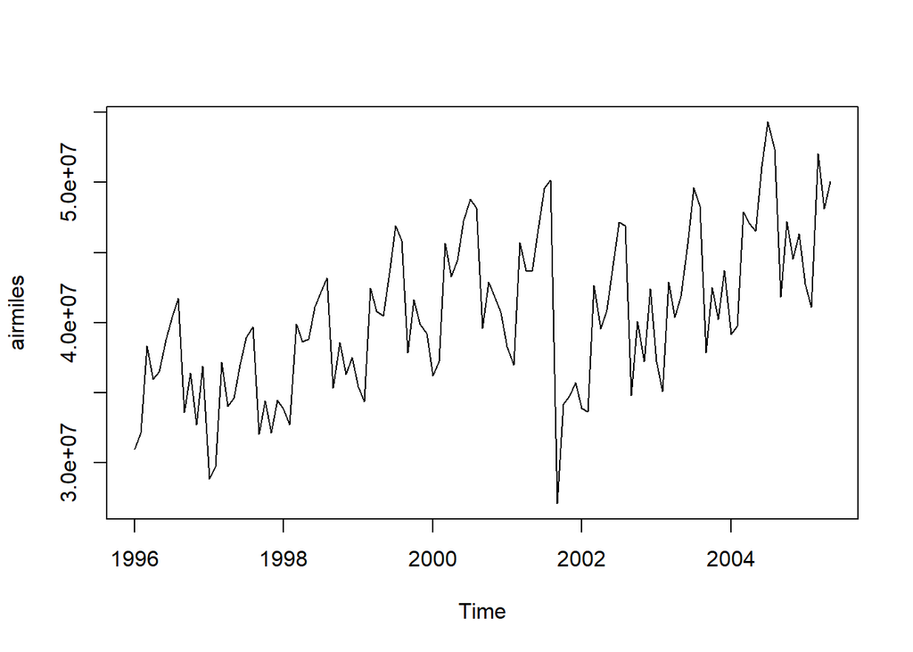

```r
data("airmiles")
View(airmiles)
plot(airmiles)
```

```r
str(airmiles)
```

```
##  Time-Series [1:113, 1] from 1996 to 2005: 30983174 32147663 38342975 35969113 36474391 38772238 40395657 41738499 33580773 36389842 ...
##  - attr(*, "dimnames")=List of 2
##   ..$ : NULL
##   ..$ : chr "airmiles"
```

Verificamos catacterísticas básicas de los datos.

```r
class(airmiles)
```

```
## [1] "ts"
```

```r
start(airmiles)
```

```
## [1] 1996    1
```

```r
end(airmiles)
```

```
## [1] 2005    5
```

```r
frequency(airmiles)
```

```
## [1] 12
```

```r
summary(airmiles)
```

```
##     airmiles
##  Min.   :27077913
##  1st Qu.:36389842
##  Median :40238253
##  Mean   :40505240
##  3rd Qu.:44060019
##  Max.   :54317314
```

Así mismo, observamos la tendecia y los ciclos.

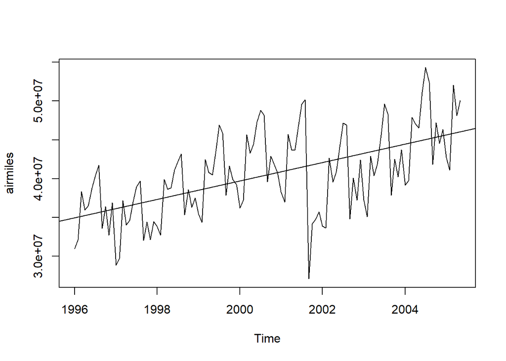

```r
plot(airmiles)
abline(reg=lm(airmiles~time(airmiles)))
```

```r
cycle(airmiles)
```

```
##      Jan Feb Mar Apr May Jun Jul Aug Sep Oct Nov Dec
## 1996   1   2   3   4   5   6   7   8   9  10  11  12
## 1997   1   2   3   4   5   6   7   8   9  10  11  12
## 1998   1   2   3   4   5   6   7   8   9  10  11  12
## 1999   1   2   3   4   5   6   7   8   9  10  11  12
## 2000   1   2   3   4   5   6   7   8   9  10  11  12
## 2001   1   2   3   4   5   6   7   8   9  10  11  12
## 2002   1   2   3   4   5   6   7   8   9  10  11  12
## 2003   1   2   3   4   5   6   7   8   9  10  11  12
## 2004   1   2   3   4   5   6   7   8   9  10  11  12
## 2005   1   2   3   4   5
```

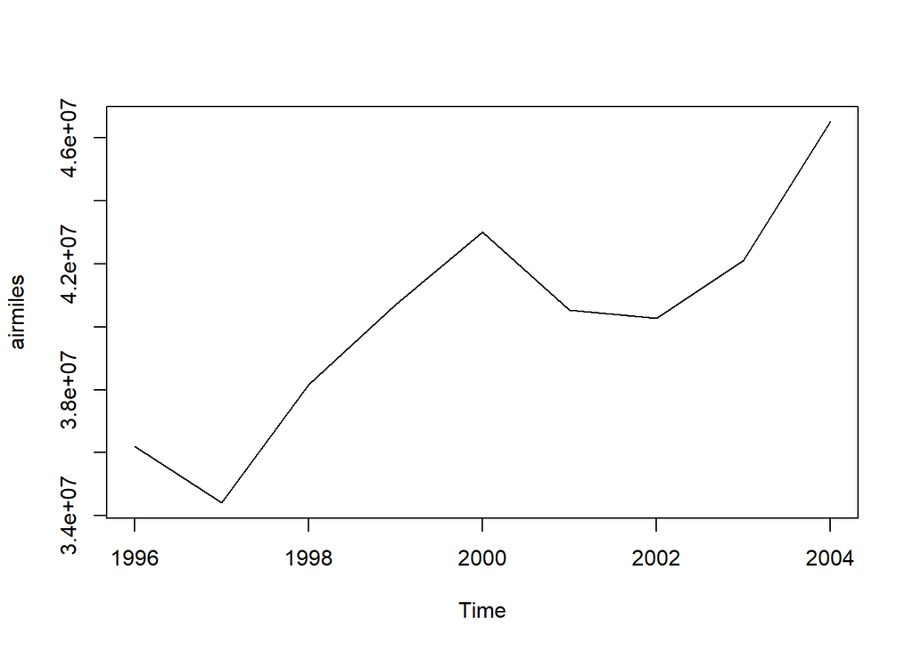

```r
plot(aggregate(airmiles,FUN=mean))
```

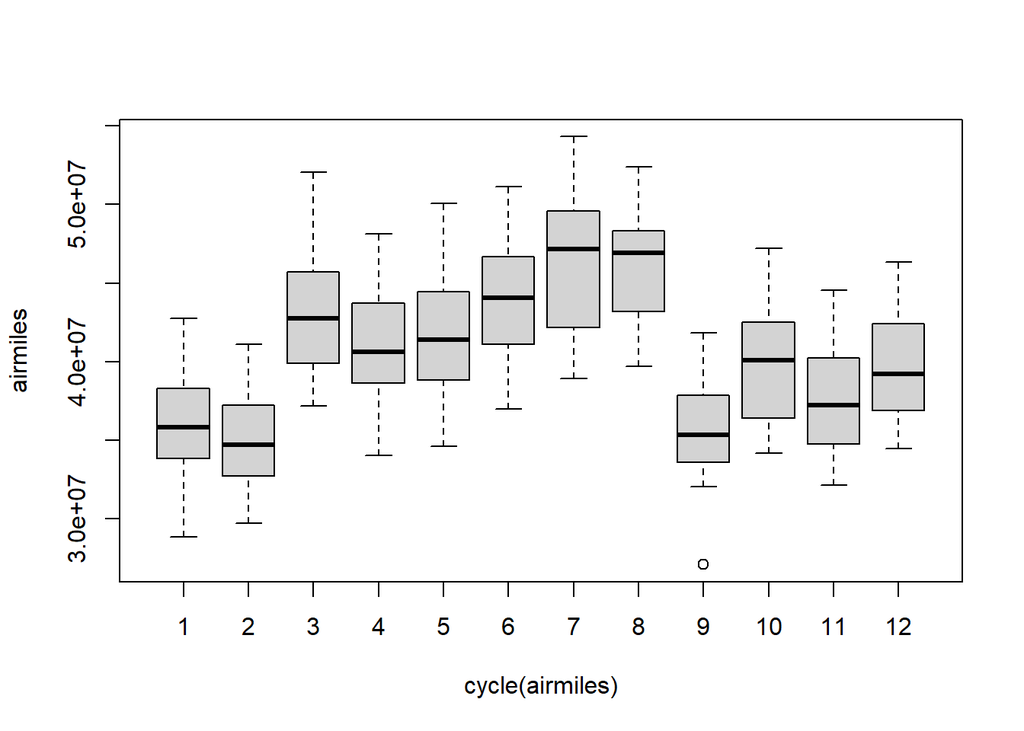

```r
boxplot(airmiles~cycle(airmiles))
```

En un intento de visualizar mejor los datos, usamos la función logaritmo (continua) y graficamos de nuevo los datos.

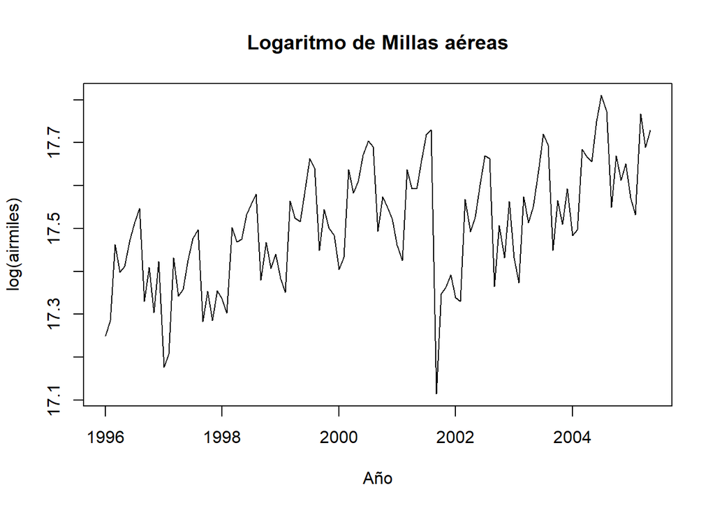

```r
plot(log(airmiles),ylab='log(airmiles)',xlab='Año', main='Logaritmo de Millas aéreas')
```

Observamos,a otra escala, la tendencia y la estacionalidad. Aplicamos el método Holt Winters, el cual permite combinar esta tendencia y también la estacionalidad. Para visualizar esto, se puede generar un modelo con la función HoltWinters.

### **Modelo Holt-Winters**

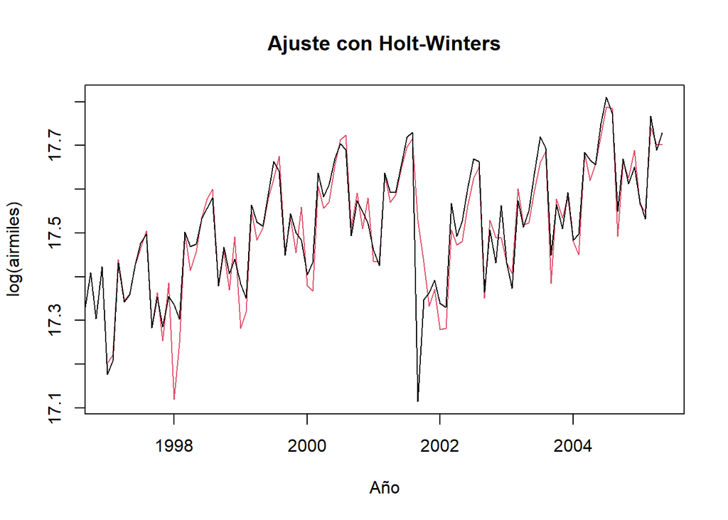

```r
modelo_HW=HoltWinters(log(airmiles), seasonal = "additive")
plot(modelo_HW, main='Ajuste con Holt-Winters',xlab='Año',ylab='log(airmiles)')
```

Se puede observar que R a través de HoltWinters crea una gráfica en color rojo, en donde se crean una nueva serie de datos que en teoría están muy cerca de los datos originales que son los de color negro.

Ahora bien, hay que tener en cuenta que la serie se debe descomponer de acuerdo a las caraceterísticas:

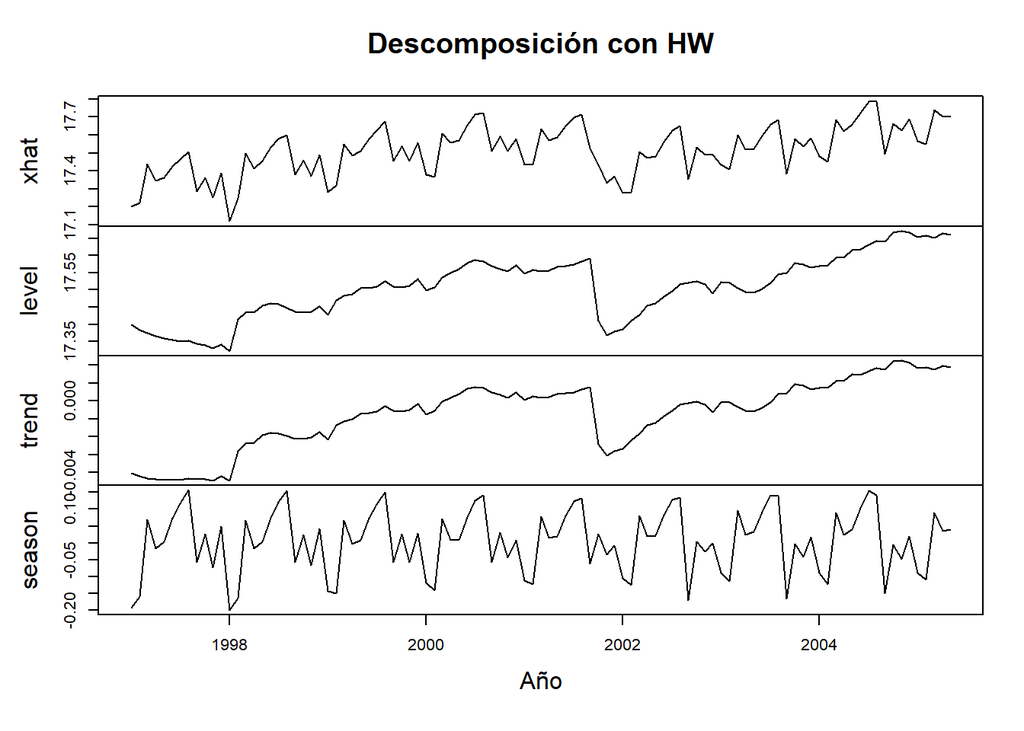

```r
plot(fitted(modelo_HW), main='Descomposición con HW',xlab='Año',ylab='log(airmiles)')
```

Algo muy importante que se puede realizar con la serie de tiempo y el método Holt Winters es **predecir**, para ello generamos lo siguiente:

```r
pred=predict(modelo_HW, 4, prediction.interval = TRUE)
pred
```

```
##               fit      upr      lwr
## Jun 2005 17.78692 17.89926 17.67457
## Jul 2005 17.84021 17.96324 17.71717
## Aug 2005 17.81899 17.95218 17.68579
## Sep 2005 17.54823 17.69118 17.40529
```

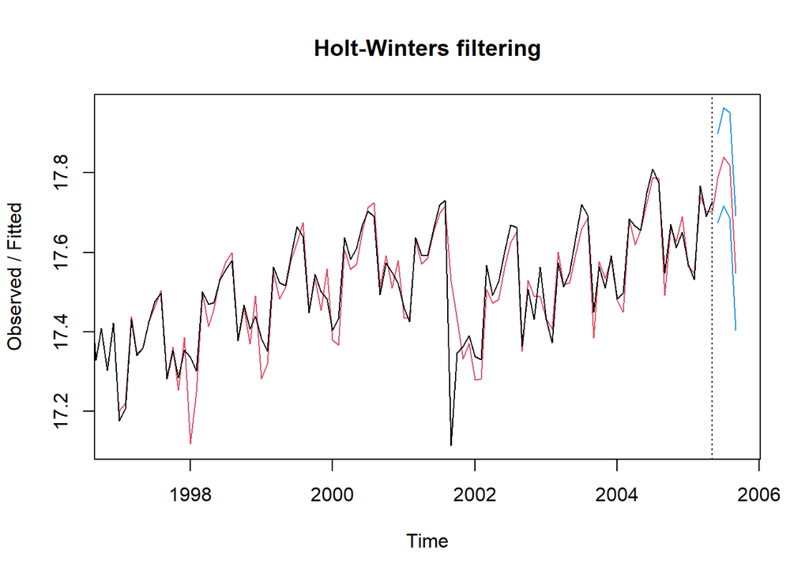

```r
plot(modelo_HW,pred)
```

## **Suavizamiento Exponencial**

La función SES Suavizado Exponencial Simple, de la librería forecast, es un tipo de promedio ponderado que estima el valor futuro en función del pronóstico anterior más un porcentaje del error pronosticado.

```r
library(forecast)
fit_ses1<-ses(log(airmiles),h=1, initial ="simple", alpha=0.1)
fit_ses1
```

```
##          Point Forecast    Lo 80    Hi 80    Lo 95    Hi 95
## Jun 2005       17.64331 17.48938 17.79723 17.40789 17.87872
```

```r
summary(fit_ses1)
```

```
##
## Forecast method: Simple exponential smoothing
##
## Model Information:
## Simple exponential smoothing
##
## Call:
##  ses(y = log(airmiles), h = 1, initial = "simple", alpha = 0.1)
##
##   Smoothing parameters:
##     alpha = 0.1
##
##   Initial states:
##     l = 17.249
##
##   sigma:  0.1201
## Error measures:
##                      ME      RMSE       MAE       MPE      MAPE     MASE
## Training set 0.03489827 0.1201116 0.0986913 0.1955602 0.5634065 1.293552
##                   ACF1
## Training set 0.3736621
##
## Forecasts:
##          Point Forecast    Lo 80    Hi 80    Lo 95    Hi 95
## Jun 2005       17.64331 17.48938 17.79723 17.40789 17.87872
```

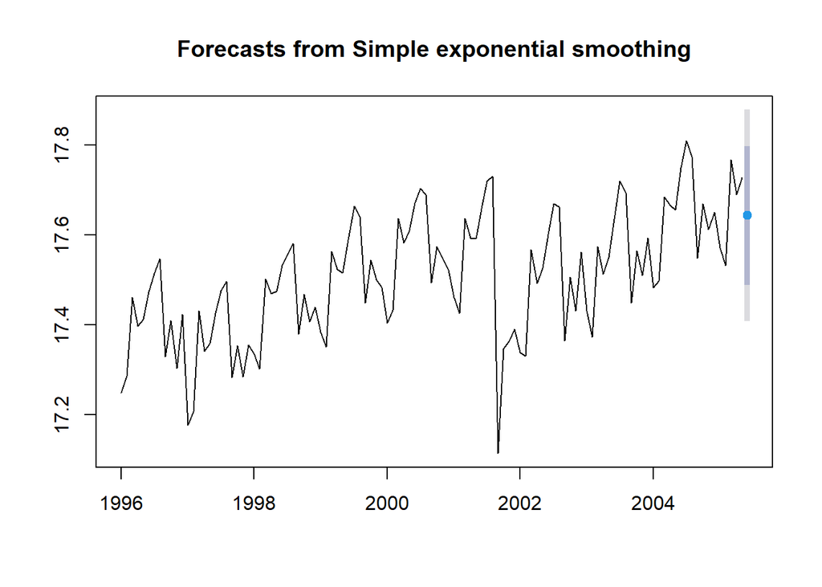

```r
plot(fit_ses1)
```

Ahora, con otro valor de $\alpha=0.7$

```r
fit_ses2<-ses(log(airmiles),h=1, initial ="simple", alpha=0.7)
fit_ses2
```

```
##          Point Forecast    Lo 80    Hi 80    Lo 95    Hi 95
## Jun 2005       17.71805 17.57217 17.86392 17.49495 17.94114
```

```r
summary(fit_ses2)
```

```
##
## Forecast method: Simple exponential smoothing
##
## Model Information:
## Simple exponential smoothing
##
## Call:
##  ses(y = log(airmiles), h = 1, initial = "simple", alpha = 0.7)
##
##   Smoothing parameters:
##     alpha = 0.7
##
##   Initial states:
##     l = 17.249
##
##   sigma:  0.1138
## Error measures:
##                       ME      RMSE        MAE        MPE      MAPE     MASE
## Training set 0.005930355 0.1138264 0.07631575 0.03115747 0.4366596 1.000275
##                    ACF1
## Training set -0.1165667
##
## Forecasts:
##          Point Forecast    Lo 80    Hi 80    Lo 95    Hi 95
## Jun 2005       17.71805 17.57217 17.86392 17.49495 17.94114
```

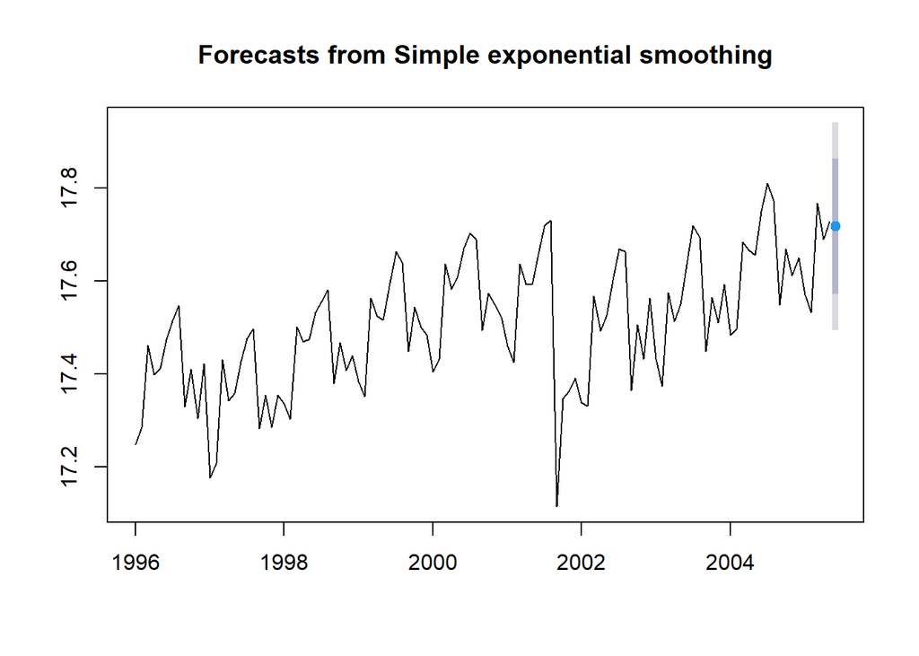

```r
plot(fit_ses2)
```

```r
fit_ses3<-ses(log(airmiles),h=1, initial ="simple", alpha=0.9)
fit_ses3
```

```
##          Point Forecast    Lo 80    Hi 80    Lo 95    Hi 95
## Jun 2005       17.72518 17.57292 17.87743 17.49232 17.95803
```

```r
summary(fit_ses3)
```

```
##
## Forecast method: Simple exponential smoothing
##
## Model Information:
## Simple exponential smoothing
##
## Call:
##  ses(y = log(airmiles), h = 1, initial = "simple", alpha = 0.9)
##
##   Smoothing parameters:
##     alpha = 0.9
##
##   Initial states:
##     l = 17.249
##
##   sigma:  0.1188
## Error measures:
##                       ME     RMSE        MAE       MPE     MAPE     MASE
## Training set 0.004682631 0.118805 0.08192678 0.0242293 0.468837 1.073819
##                    ACF1
## Training set -0.2673554
##
## Forecasts:
##          Point Forecast    Lo 80    Hi 80    Lo 95    Hi 95
## Jun 2005       17.72518 17.57292 17.87743 17.49232 17.95803
```

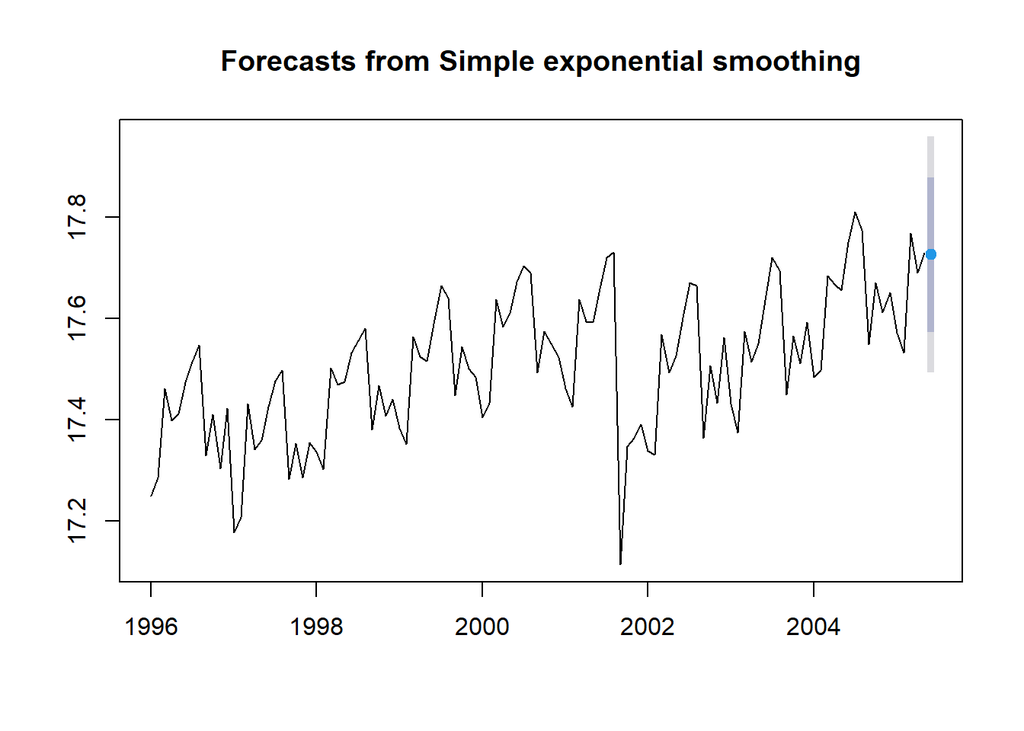

```r
plot(fit_ses3)
```

Lo mejor, es correr el modelo mediante un valor $\alpha$ automático que considera el menor error en las métricas de exactitud en el pronóstico (simplemente no se define el parámetro $\alpha$)

```r
fit_ses<-ses(log(airmiles),h=1, initial ="simple")
fit_ses
```

```
##          Point Forecast    Lo 80    Hi 80    Lo 95    Hi 95
## Jun 2005       17.70431 17.56057 17.84804 17.48449 17.92413
```

```r
summary(fit_ses)
```

```
##
## Forecast method: Simple exponential smoothing
##
## Model Information:
## Simple exponential smoothing
##
## Call:
##  ses(y = log(airmiles), h = 1, initial = "simple")
##
##   Smoothing parameters:
##     alpha = 0.5041
##
##   Initial states:
##     l = 17.249
##
##   sigma:  0.1122
## Error measures:
##                       ME      RMSE      MAE        MPE      MAPE     MASE
## Training set 0.007993827 0.1121561 0.080706 0.04265741 0.4615475 1.057818
##                    ACF1
## Training set 0.04846846
##
## Forecasts:
##          Point Forecast    Lo 80    Hi 80    Lo 95    Hi 95
## Jun 2005       17.70431 17.56057 17.84804 17.48449 17.92413
```

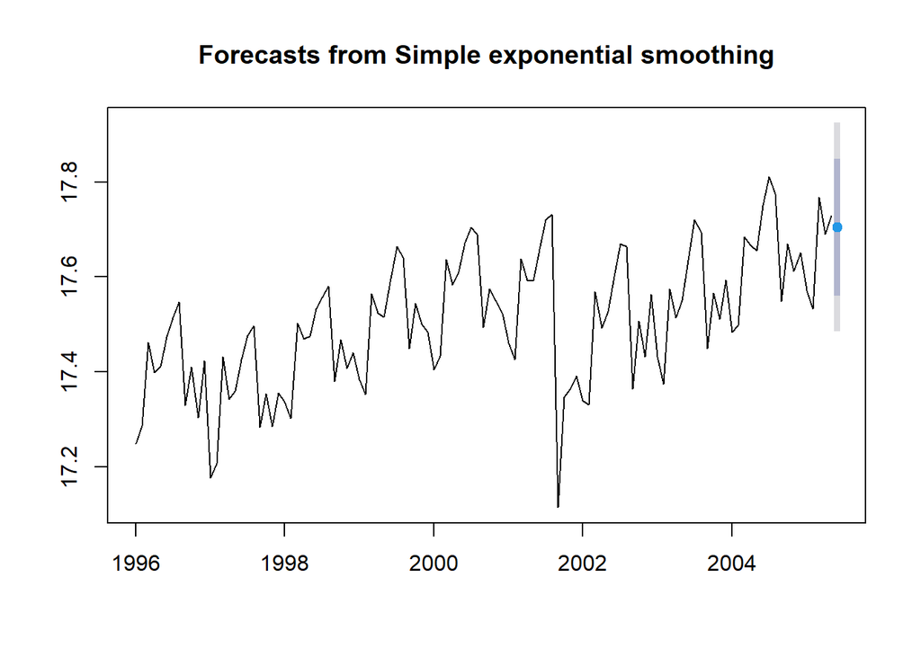

```r
plot(fit_ses)
```

## **Promedio móvil**

```r
library(TTR)
lairmiles=log(airmiles)

sm<-SMA(lairmiles, n = 10) # media móvil simple

EMA(lairmiles, n = 10, wilder = FALSE, ratio = NULL) # exponencial
```

```
##           Jan      Feb      Mar      Apr      May      Jun      Jul      Aug
## 1996       NA       NA       NA       NA       NA       NA       NA       NA
## 1997 17.35557 17.32859 17.34726 17.34629 17.34859 17.36265 17.38341 17.40411
## 1998 17.35506 17.34551 17.37398 17.39130 17.40643 17.42926 17.45245 17.47577
## 1999 17.43676 17.42131 17.44721 17.46129 17.47122 17.49262 17.52377 17.54503
## 2000 17.49718 17.48549 17.51301 17.52570 17.54107 17.56474 17.59002 17.60821
## 2001 17.54886 17.52645 17.54661 17.55506 17.56183 17.57937 17.60484 17.62776
## 2002 17.43814 17.41860 17.44579 17.45433 17.46745 17.49174 17.52407 17.54943
## 2003 17.49643 17.47412 17.49239 17.49625 17.50606 17.52955 17.56421 17.58778
## 2004 17.54665 17.53776 17.56437 17.58299 17.59621 17.62416 17.65801 17.67915
## 2005 17.63565 17.61681 17.64426 17.65255 17.66636
##           Sep      Oct      Nov      Dec
## 1996       NA 17.40808 17.38915 17.39527
## 1997 17.38204 17.37690 17.36019 17.35924
## 1998 17.45830 17.46006 17.45043 17.44856
## 1999 17.52749 17.53065 17.52531 17.51779
## 2000 17.58738 17.58502 17.57857 17.56836
## 2001 17.53439 17.50036 17.47551 17.46022
## 2002 17.51580 17.51414 17.49924 17.51081
## 2003 17.56261 17.56308 17.55349 17.56064
## 2004 17.65545 17.65810 17.64976 17.64999
## 2005
```

```r
DEMA(lairmiles, n = 10, v = 1, wilder = FALSE, ratio = NULL) # exponencial doble
```

```
##           Jan      Feb      Mar      Apr      May      Jun      Jul      Aug
## 1996       NA       NA       NA       NA       NA       NA       NA       NA
## 1997       NA       NA       NA       NA       NA       NA 17.40034 17.43490
## 1998 17.34274 17.32761 17.38263 17.41255 17.43621 17.47230 17.50664 17.53918
## 1999 17.43821 17.40985 17.45904 17.48248 17.49669 17.53096 17.58062 17.60894
## 2000 17.49077 17.47069 17.52341 17.54459 17.56911 17.60704 17.64531 17.66833
## 2001 17.53589 17.49750 17.53941 17.55610 17.56821 17.59893 17.64168 17.67667
## 2002 17.36468 17.34251 17.40578 17.42857 17.45712 17.50317 17.55987 17.59946
## 2003 17.48953 17.45021 17.48778 17.49563 17.51358 17.55492 17.61332 17.64725
## 2004 17.54752 17.53121 17.58078 17.61164 17.63047 17.67506 17.72736 17.75319
## 2005 17.63914 17.60425 17.65644 17.66931 17.69137
##           Sep      Oct      Nov      Dec
## 1996       NA       NA       NA       NA
## 1997 17.38917 17.37852 17.34785 17.34836
## 1998 17.49588 17.49225 17.46889 17.46214
## 1999 17.56544 17.56427 17.54845 17.53057
## 2000 17.61954 17.60940 17.59324 17.57201
## 2001 17.49801 17.44274 17.40804 17.39251
## 2002 17.52921 17.52377 17.49493 17.51673
## 2003 17.59068 17.58643 17.56475 17.57570
## 2004 17.69664 17.69397 17.67227 17.66859
## 2005
```

```r
#WMA(lairmiles, n = 10, wts = 1:n) #(linear weighting) Ponderada

#EVWMA(lairmiles, volume, n = 10) #Promedio movil elastico ponderado por volumen

HMA(lairmiles, n = 20) # Hull moving average
```

```
##           Jan      Feb      Mar      Apr      May      Jun      Jul      Aug
## 1996       NA       NA       NA       NA       NA       NA       NA       NA
## 1997       NA       NA       NA       NA       NA       NA       NA       NA
## 1998 17.36627 17.35364 17.36017 17.37508 17.39579 17.42542 17.46080 17.50021
## 1999 17.48598 17.45807 17.44993 17.45191 17.46086 17.48152 17.51549 17.55408
## 2000 17.54881 17.52003 17.51211 17.51408 17.52636 17.55075 17.58406 17.61998
## 2001 17.59190 17.55565 17.53787 17.53078 17.53277 17.54803 17.57646 17.61342
## 2002 17.40084 17.36236 17.35298 17.35718 17.37611 17.41332 17.46881 17.52962
## 2003 17.54189 17.51485 17.50148 17.49100 17.48991 17.50602 17.54150 17.58427
## 2004 17.58822 17.57091 17.57024 17.57852 17.59303 17.62104 17.66212 17.70480
## 2005 17.68831 17.65791 17.64802 17.64464 17.65175
##           Sep      Oct      Nov      Dec
## 1996       NA       NA       NA       NA
## 1997       NA       NA 17.38173 17.37458
## 1998 17.51715 17.52427 17.51755 17.50564
## 1999 17.57207 17.58219 17.58126 17.57178
## 2000 17.63337 17.63726 17.63181 17.61746
## 2001 17.58700 17.54135 17.48854 17.44111
## 2002 17.55498 17.56617 17.55880 17.55499
## 2003 17.60111 17.60791 17.60250 17.59969
## 2004 17.72030 17.72567 17.71826 17.70778
## 2005
```

```r
ALMA(lairmiles, n = 9, offset = 0.85, sigma = 6) #Arnaud Legoux moving average
```

```
##           Jan      Feb      Mar      Apr      May      Jun      Jul      Aug
## 1996       NA       NA       NA       NA       NA       NA       NA       NA
## 1997 17.35345 17.31290 17.29255 17.29591 17.32264 17.35422 17.38476 17.41909
## 1998 17.33121 17.32760 17.34644 17.37936 17.42069 17.45972 17.49101 17.51993
## 1999 17.43009 17.41223 17.41582 17.43911 17.47567 17.51288 17.54923 17.58486
## 2000 17.49665 17.47133 17.47211 17.49852 17.54273 17.58633 17.62301 17.65343
## 2001 17.53918 17.51013 17.50195 17.51692 17.54983 17.58548 17.61949 17.65519
## 2002 17.35180 17.35412 17.37680 17.41210 17.45881 17.50417 17.54771 17.59077
## 2003 17.48092 17.46986 17.46700 17.47237 17.49541 17.53050 17.57566 17.62342
## 2004 17.53965 17.53160 17.54020 17.56737 17.60754 17.65067 17.69273 17.73088
## 2005 17.62962 17.61042 17.61122 17.62915 17.66509
##           Sep      Oct      Nov      Dec
## 1996 17.47448 17.46065 17.42024 17.38992
## 1997 17.42857 17.41374 17.37494 17.34437
## 1998 17.52288 17.50708 17.47419 17.44830
## 1999 17.59403 17.58041 17.54947 17.52248
## 2000 17.65330 17.63000 17.59362 17.56383
## 2001 17.61879 17.53220 17.42634 17.36470
## 2002 17.59378 17.56644 17.51588 17.48966
## 2003 17.63558 17.61678 17.57555 17.55140
## 2004 17.73443 17.71189 17.67186 17.64578
## 2005
```

```r
ZLEMA(lairmiles, n = 10, ratio = NULL) #Zero lag exponential moving average.
```

```
##           Jan      Feb      Mar      Apr      May      Jun      Jul      Aug
## 1996       NA       NA       NA       NA       NA       NA       NA       NA
## 1997 17.26383 17.21153 17.26269 17.27438 17.28895 17.33678 17.41402 17.46153
## 1998 17.31313 17.29530 17.36633 17.41229 17.45171 17.50020 17.55366 17.59101
## 1999 17.40912 17.37534 17.43505 17.46718 17.49282 17.54247 17.61841 17.65572
## 2000 17.45993 17.43470 17.49692 17.52340 17.56059 17.62198 17.68869 17.71716
## 2001 17.49861 17.45511 17.50701 17.52833 17.55020 17.60012 17.67201 17.71899
## 2002 17.25998 17.25612 17.37421 17.42072 17.46704 17.53431 17.61978 17.66666
## 2003 17.45612 17.41562 17.46981 17.48580 17.50709 17.55548 17.64314 17.69230
## 2004 17.51731 17.50033 17.56590 17.60768 17.63534 17.69468 17.77382 17.80724
## 2005 17.60271 17.56631 17.63173 17.65117 17.68285
##           Sep      Oct      Nov      Dec
## 1996       NA 17.40808 17.36393 17.36174
## 1997 17.41013 17.40048 17.35996 17.34151
## 1998 17.53331 17.52072 17.48258 17.45592
## 1999 17.60068 17.59499 17.56865 17.52735
## 2000 17.65541 17.63666 17.60424 17.55934
## 2001 17.51795 17.44226 17.38041 17.32833
## 2002 17.58153 17.56740 17.51889 17.51370
## 2003 17.63091 17.62501 17.58918 17.57441
## 2004 17.73723 17.72661 17.68933 17.65888
## 2005
```

```r
#VWAP(lairmiles, volume, n = 10)#Volume-weighed moving average

#VMA(lairmiles, w, ratio = 1)
```